# Homework 1 (Fatos estilizados)

## Questão 2. Extra

*Calcule as principais estatı́sticas descritivas das variáveis: média, desvio-padrão, variância, curtose, assimetria, etc.*

## Resposta 2:

Iremos realizar o cálculos de nosso sumário estatístico para cada um dos 4 ativos aqui analisados utilizando o pacote `fBasics` (https://rdocumentation.org/packages/fBasics/versions/4022.94).

### PETR3

```r
petro3 <- assets %>%
  filter(ticker=="PETR3.SA")

daily_returns_petro3 <- petro3 %>%
  select(ref.date, ticker, ret.closing.prices)

# "package to investigate basic properties of financial returns
# and related quantities" [fonte: help]
library(fBasics)
# ?fBasics

# computa resumo estatístico
basicStats(daily_returns_petro3$ret.closing.prices)
```

```
##             X..daily_returns_petro3.ret.closing.prices
## nobs                                       1117.000000
## NAs                                           1.000000
## Minimum                                      -0.352054
## Maximum                                       0.205024
## 1. Quartile                                  -0.012887
## 3. Quartile                                   0.015391
## Mean                                          0.000194
## Median                                        0.001097
## Sum                                           0.216744
## SE Mean                                       0.000948
## LCL Mean                                     -0.001665
## UCL Mean                                      0.002053
## Variance                                      0.001002
## Stdev                                         0.031653
## Skewness                                     -2.153570
## Kurtosis                                     22.775560
```

### PETR4

```r
petro4 <- assets %>%
  filter(ticker=="PETR4.SA")

daily_returns_petro4 <- petro4 %>%
  select(ref.date, ticker, ret.closing.prices)

# computa resumo estatístico
basicStats(daily_returns_petro4$ret.closing.prices)
```

```
##             X..daily_returns_petro4.ret.closing.prices
## nobs                                       1117.000000
## NAs                                           1.000000
## Minimum                                      -0.352367
## Maximum                                       0.200671
## 1. Quartile                                  -0.012532
## 3. Quartile                                   0.015650
## Mean                                          0.000184
## Median                                        0.001133
## Sum                                           0.204856
## SE Mean                                       0.000932
## LCL Mean                                     -0.001645
## UCL Mean                                      0.002012
## Variance                                      0.000969
## Stdev                                         0.031135
## Skewness                                     -2.223955
## Kurtosis                                     23.194841
```

### VALE3

```r
vale <- assets %>%
  filter(ticker=="VALE3.SA")

daily_returns_vale <- vale %>%
  select(ref.date, ticker, ret.closing.prices)

# computa resumo estatístico
basicStats(daily_returns_vale$ret.closing.prices)
```

```
##             X..daily_returns_vale.ret.closing.prices
## nobs                                     1117.000000
## NAs                                         1.000000
## Minimum                                    -0.281822
## Maximum                                     0.193574
## 1. Quartile                                -0.013494
## 3. Quartile                                 0.012907
## Mean                                        0.000205
## Median                                      0.000000
## Sum                                         0.228726
## SE Mean                                     0.000795
## LCL Mean                                   -0.001354
## UCL Mean                                    0.001764
## Variance                                    0.000705
## Stdev                                       0.026548
## Skewness                                   -0.776034
## Kurtosis                                   17.340391
```

### JBSS3

```r
jbs <- assets %>%
  filter(ticker=="JBSS3.SA")

daily_returns_jbs <- jbs %>%
  select(ref.date, ticker, ret.closing.prices)

# computa resumo estatístico
basicStats(daily_returns_jbs$ret.closing.prices)
```

```
##             X..daily_returns_jbs.ret.closing.prices
## nobs                                    1117.000000
## NAs                                        1.000000
## Minimum                                   -0.154627
## Maximum                                    0.219915
## 1. Quartile                               -0.014014
## 3. Quartile                                0.014224
## Mean                                       0.000333
## Median                                     0.000000
## Sum                                        0.371678
## SE Mean                                    0.000816
## LCL Mean                                  -0.001268
## UCL Mean                                   0.001934
## Variance                                   0.000743
## Stdev                                      0.027259
## Skewness                                   0.422424
## Kurtosis                                   8.087909
```

### Testes de hipótese da normalidade para média e curtose

Calculemos os testes de [t-Student](https://en.wikipedia.org/wiki/Student's_t-test) e de [`Jarque-Bera`](https://www.rdocumentation.org/packages/fBasics/versions/4022.94/topics/NormalityTests) para rejeitarmos (ou não) as hipóteses nulas de média zero e de curtose K=3, respectivamente.

#### PETR3

```r
# ?t.test
# teste de t-Student para normalidade
t.test(na.exclude(daily_returns_petro3$ret.closing.prices))
```

```
##
##  One Sample t-test
##
## data:  na.exclude(daily_returns_petro3$ret.closing.prices)
## t = 0.20498, df = 1115, p-value = 0.8376
## alternative hypothesis: true mean is not equal to 0
## 95 percent confidence interval:
##  -0.001664878  0.002053309
## sample estimates:
##    mean of x
## 0.0001942151
```

Como o p do teste acima foi p > 0.05, então não podemos rejeitar a hipótese nula de que a média da distribuição é Normal (i.e., a média é zero).

```r
# ?jarqueberaTest
# teste de Jarque-Bera para normalidade
jarqueberaTest(na.exclude(daily_returns_petro3$ret.closing.prices))
```

```
##
## Title:
##  Jarque - Bera Normalality Test
##
## Test Results:
##   STATISTIC:
##     X-squared: 25083.804
##   P VALUE:
##     Asymptotic p Value: < 2.2e-16
```

Como o p do teste foi p < 0.05, então rejeitamos a hipótese nula de que a curtose K da distribuição é Normal (K=3). Portanto, a distribuição dos retornos da PETR3 tem cauda pesada.

#### PETR4, VALE3, JBSS3

```r
print("PETR4")
```

```
## [1] "PETR4"
```

```r
# teste de t-Student para normalidade
t.test(na.exclude(daily_returns_petro4$ret.closing.prices))
```

```
##
##  One Sample t-test
##
## data:  na.exclude(daily_returns_petro4$ret.closing.prices)
## t = 0.19696, df = 1115, p-value = 0.8439
## alternative hypothesis: true mean is not equal to 0
## 95 percent confidence interval:
##  -0.001645099  0.002012225
## sample estimates:
##    mean of x
## 0.0001835628
```

```r
# teste de Jarque-Bera para normalidade
jarqueberaTest(na.exclude(daily_returns_petro4$ret.closing.prices))
```

```
##
## Title:
##  Jarque - Bera Normalality Test
##
## Test Results:
##   STATISTIC:
##     X-squared: 26040.9628
##   P VALUE:
##     Asymptotic p Value: < 2.2e-16
```

```r
print("VALE3")
```

```
## [1] "VALE3"
```

```r
t.test(na.exclude(daily_returns_vale$ret.closing.prices))
```

```
##
##  One Sample t-test
##
## data:  na.exclude(daily_returns_vale$ret.closing.prices)
## t = 0.2579, df = 1115, p-value = 0.7965
## alternative hypothesis: true mean is not equal to 0
## 95 percent confidence interval:
##  -0.001354328  0.001764232
## sample estimates:
##    mean of x
## 0.0002049515
```

```r
jarqueberaTest(na.exclude(daily_returns_vale$ret.closing.prices))
```

```
##
## Title:
##  Jarque - Bera Normalality Test
##
## Test Results:
##   STATISTIC:
##     X-squared: 14153.2883
##   P VALUE:
##     Asymptotic p Value: < 2.2e-16
```

```r
print("JBSS3")
```

```
## [1] "JBSS3"
```

```r
t.test(na.exclude(daily_returns_jbs$ret.closing.prices))
```

```
##
##  One Sample t-test
##
## data:  na.exclude(daily_returns_jbs$ret.closing.prices)
## t = 0.40816, df = 1115, p-value = 0.6832
## alternative hypothesis: true mean is not equal to 0
## 95 percent confidence interval:
##  -0.001267971  0.001934061
## sample estimates:
##    mean of x
## 0.0003330449
```

```r
jarqueberaTest(na.exclude(daily_returns_jbs$ret.closing.prices))
```

```
##
## Title:
##  Jarque - Bera Normalality Test
##
## Test Results:
##   STATISTIC:
##     X-squared: 3090.0282
##   P VALUE:
##     Asymptotic p Value: < 2.2e-16
```

O valor do p do teste de t-Student foi p > 0.05 para PETR4, VALE3 e JBSS3. Logo, não podemos rejeitar a hipótese nula de que a média é zero).

Além do mais, como o p do teste de Jarque-Bera foi p < 0.05 para PETR4, VALE e JBSS3, então rejeitamos a hipótese nula de que a curtose da distribuição é Normal (K=3). Portanto, concluímos que a distribuição dos retornos dos ativos PETR4, VALE3 e JBSS3 tem cauda pesada.

### Gráficos em comparação com a distribuição Normal

Abaixo refizemos o gráfico dos histograma dos 4 ativos, acrescentando o gráfico de uma distribuição Normal com média e variância iguais a um dos ativos. Apenas para fins de comparação, fixamos o mesmo valor para os 4 gráficos.

Para simplificar, ao invés de considerarmos as distribuições Normais com mesma média e variância, escolhemos fixar esses valores no ativo com maior variância $\sigma^2$ (o que equivale a maior desvio padrão $\sigma$). Portanto, adicionamos aos histogramas a distribuição Normal com média = 0 e $\sigma$ = 0.031653 (desvio padrão da PETR3). Além disso, buscando melhorar a visualização, também reduzimos o intervalo do eixo x dos gráficos.

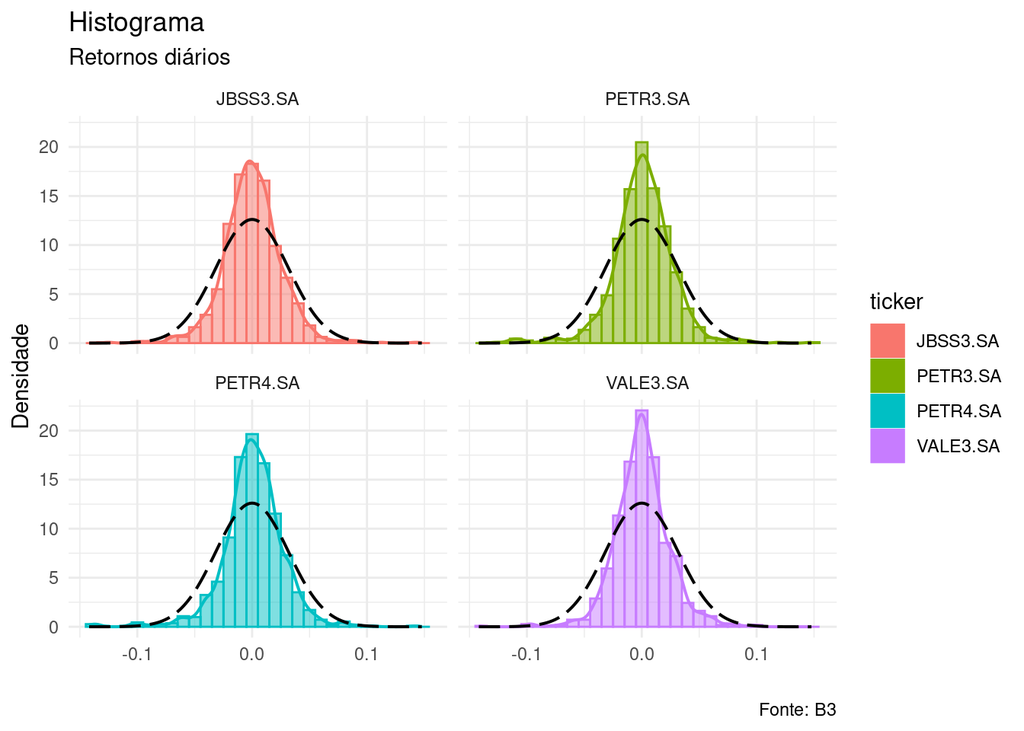

```r
# histograma
xmin <- -0.15
xmax <- 0.15
assests_subset <- assets[assets$ret.closing.prices>=xmin &
                           assets$ret.closing.prices<=xmax, ]

petro3_subset <- petro3[petro3$ret.closing.prices>=xmin &
                         petro3$ret.closing.prices<=xmax, ]

histogram0 <- ggplot(data=na.exclude(assests_subset)) +
  geom_histogram(aes(x=ret.closing.prices,
                        y=after_stat(density),
                     fill=ticker, color=ticker),
                 linetype=1, alpha=0.5, bins=30, na.rm=TRUE) +
  geom_density(aes(x=ret.closing.prices, y=after_stat(density), color=ticker),
               na.rm=TRUE, linewidth=0.7) +
  stat_function(data=assets,
                fun=dnorm,
                n=length(na.exclude(petro3_subset$ret.closing.prices)),
                args=list(mean=0,
                          sd=0.031653),
                linetype=5, linewidth=0.7) +
  labs(x="", y="Densidade", title="Histograma",
       subtitle="Retornos diários",
       caption="Fonte: B3") +
  theme_minimal() +
  facet_wrap(~ticker, nrow=2)
histogram0
```

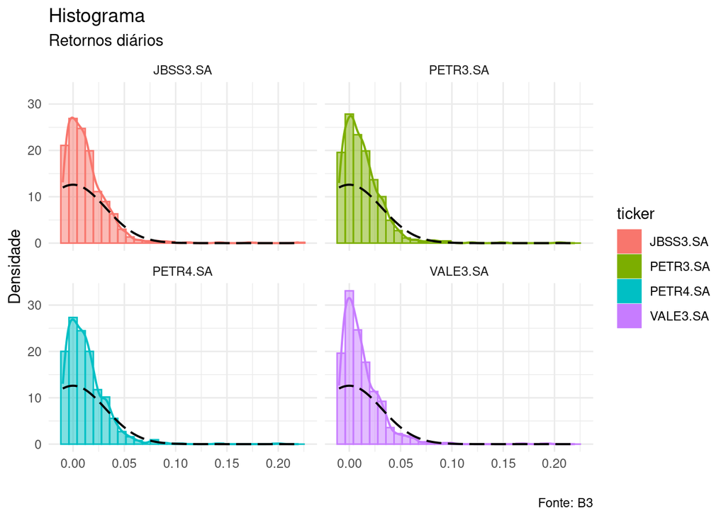

```r
# histograma
xmin <- -0.01
xmax <- 0.4
assests_subset <- assets[assets$ret.closing.prices>=xmin &
                           assets$ret.closing.prices<=xmax, ]

petro3_subset <- petro3[petro3$ret.closing.prices>=xmin &
                         petro3$ret.closing.prices<=xmax, ]

histogram2 <- ggplot(data=na.exclude(assests_subset)) +
  geom_histogram(aes(x=ret.closing.prices,
                        y=after_stat(density),
                     fill=ticker, color=ticker),
                 linetype=1, alpha=0.5, bins=30, na.rm=TRUE) +
  geom_density(aes(x=ret.closing.prices, y=after_stat(density), color=ticker),
               na.rm=TRUE, linewidth=0.7) +
  stat_function(data=assets,
                fun=dnorm,
                n=length(na.exclude(petro3_subset$ret.closing.prices)),
                args=list(mean=0,
                          sd=0.031653),
                linetype=5, linewidth=0.7) +
  labs(x="", y="Densidade", title="Histograma",
       subtitle="Retornos diários",
       caption="Fonte: B3") +
  theme_minimal() +
  facet_wrap(~ticker, nrow=2)
histogram2
```

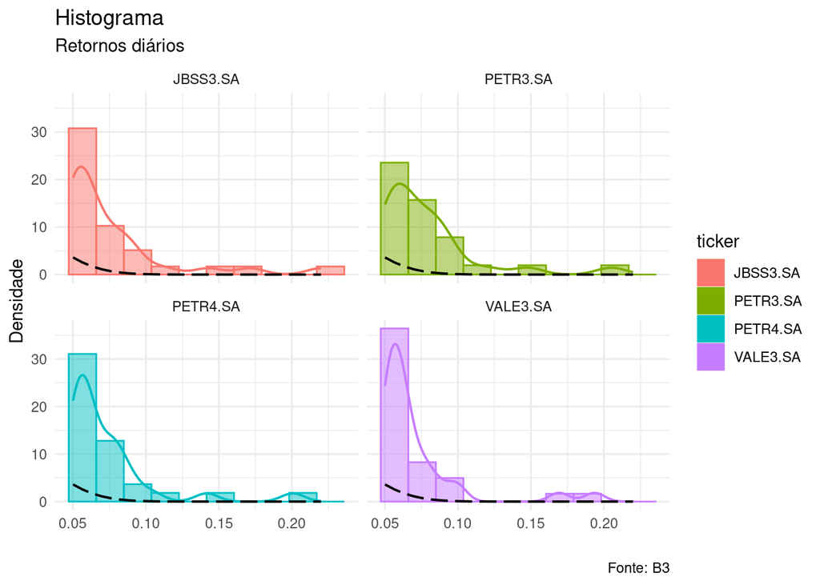

```r
# class(histogram2)

# histograma
xmin <- 0.05
xmax <- 0.4
assests_subset <- assets[assets$ret.closing.prices>=xmin &
                           assets$ret.closing.prices<=xmax, ]

petro3_subset <- petro3[petro3$ret.closing.prices>=xmin &
                         petro3$ret.closing.prices<=xmax, ]

histogram3 <- ggplot(data=na.exclude(assests_subset)) +
  geom_histogram(aes(x=ret.closing.prices,
                        y=after_stat(density),
                     fill=ticker, color=ticker),
                 linetype=1, alpha=0.5, bins=10, na.rm=TRUE) +
  geom_density(aes(x=ret.closing.prices, y=after_stat(density), color=ticker),
               na.rm=TRUE, linewidth=0.7) +
  stat_function(data=assets,
                fun=dnorm,
                n=length(na.exclude(petro3_subset$ret.closing.prices)),
                args=list(mean=0,
                          sd=0.031653),
                linetype=5, linewidth=0.7) +
  labs(x="", y="Densidade", title="Histograma",
       subtitle="Retornos diários",
       caption="Fonte: B3") +
  theme_minimal() +
  facet_wrap(~ticker, nrow=2)
histogram3
```

Pelas linhas tracejada em preto nos gráficos acima, referentes a distribuição Normal, notamos que a média da distribuição calculada é zero. Além disso, os gráfico que focam nas caudas das distribuções, mostram o efeito de cauda pesada dos retornos. A parte colorida fica acima da linha tracejada conforme analisamos as extremidades das caudas de cada uma das 4 distribuições dos respectivos ativos.